# Ovarian Cancer Risk Prediction Using `miRNA` Data

Saheed

# Objective

To predict ovarian cancer risk using miRNA expression profiles

## Work done so far…

- Preprocessed the RAW and Annotated datasets
- Implented TPM Normalization
- Built an initial LASSO linear regression model using glmnet and performed LOOCV
- Extracted the most informative features (using LASSO)
- Rebuilt a linear model with these selected features
- Extended this approach to logistic regression, decision trees, and PCA for comparison

## What does the data look like?

(Post data-preprocessing and TPM normalization)

Dimensions - 403 x 80

```
              X45_R1_adapt10 X38_R1_adapt10 X48_R1_adapt10 X31_R1_adapt10
hsa-let-7a-3p      11.102313       11.36950      10.871387       10.27570
hsa-let-7a-5p      14.496149       15.17878      15.550171       14.86019
hsa-let-7b-3p       9.574263       10.18256       9.744876        9.57021
hsa-let-7b-5p      15.662297       15.65393      15.112645       15.24988
hsa-let-7c-5p      12.900548       13.42160      13.447848       12.89724
hsa-let-7d-3p      12.732364       13.20445      13.123060       12.93529
hsa-let-7d-5p      12.560831       12.90173      13.099413       12.69374
              X56_R1_adapt10 X25_R1_adapt10 X41_R1_adapt10 X18_R1_adapt10
hsa-let-7a-3p      10.341933      10.138788       9.515224       9.994657
hsa-let-7a-5p      14.999068      14.849064      13.654659      14.558400
hsa-let-7b-3p       9.414431       9.620006       8.654156       9.218252
hsa-let-7b-5p      14.813757      15.131764      15.007989      14.614050
hsa-let-7c-5p      12.830927      12.903420      11.961366      12.563208
hsa-let-7d-3p      12.158386      12.872398      12.495483      12.334900
hsa-let-7d-5p      12.765603      12.621173      11.347701      11.692143
              X16_R1_adapt10 X79_R1_adapt10 X10_R1_adapt10 X63_R1_adapt10
hsa-let-7a-3p       9.821731       8.083554       11.55528      10.784757
hsa-let-7a-5p      14.121195      12.459230       14.74316      14.634981
hsa-let-7b-3p       9.509623       7.265679       10.14346       9.687909
hsa-let-7b-5p      15.206517      13.906760       16.42045      16.529523
hsa-let-7c-5p      12.347511      10.543060       13.21244      13.038856
hsa-let-7d-3p      12.427637      10.099994       13.23028      12.921449
hsa-let-7d-5p      11.266515       9.322892       12.46093      12.391966
              X64_R1_adapt10 X52_R1_adapt10 X9_R1_adapt10 X15_R1_adapt10
hsa-let-7a-3p      10.704613      10.428854      9.633175      10.656113
hsa-let-7a-5p      15.258406      15.354842     12.679165      14.888924
hsa-let-7b-3p       9.599436       9.545433      8.339323       9.292032
hsa-let-7b-5p      15.178340      15.366537     14.999957      15.686875
hsa-let-7c-5p      13.189283      13.208382     11.094282      13.066300
hsa-let-7d-3p      13.085224      13.086231     11.890186      12.804455
hsa-let-7d-5p      13.151841      13.108098     11.117292      12.532533
              X1_R1_adapt10 X35_R1_adapt10 X27_R1_adapt10 X33_R1_adapt10
hsa-let-7a-3p      11.44969      10.708744      10.120547       9.088612
hsa-let-7a-5p      14.81726      15.228020      13.957306      14.527651
hsa-let-7b-3p       9.54263       8.886156       8.763472       7.653552
hsa-let-7b-5p      16.13501      14.205747      14.953113      14.172029
hsa-let-7c-5p      13.23031      13.127296      12.225843      11.979764
hsa-let-7d-3p      13.42755      12.135002      12.657052      12.535217
hsa-let-7d-5p      11.94344      12.941938      11.792695      11.674148
```

[output cut: 81 more lines]

```
hsa-let-7a-3p   9.719106  10.923348  10.375732   10.62418  10.134289   11.42690
hsa-let-7a-5p  14.858834  14.759114  14.023833   13.77343  14.863957   14.88096
hsa-let-7b-3p   9.598724   9.405286   9.086054    9.79087   9.458217   10.29743
hsa-let-7b-5p  15.356726  14.919905  15.398863   15.79062  15.345692   16.94811
hsa-let-7c-5p  12.723838  13.025098  12.842680   12.66856  13.025259   13.76225
hsa-let-7d-3p  13.569693  12.559844  12.817962   12.45283  12.808092   13.33581
hsa-let-7d-5p  12.529040  11.843834  10.510195   11.52618  12.360120   12.28162
              SRR5230731 SRR5230736
hsa-let-7a-3p  10.627106  10.290558
hsa-let-7a-5p  14.214165  14.061663
hsa-let-7b-3p   8.525501   9.378099
hsa-let-7b-5p  14.121599  15.719480
hsa-let-7c-5p  11.871672  12.570112
hsa-let-7d-3p  11.440034  12.586867
hsa-let-7d-5p  12.235655  11.501490
```

## Lasso

- Selected important (13) features and trained the model
- Made predictions using the “FH.B4” group as test-set
- Features
- Test-set (FH.B4)
- Lasso-pred

```
 [1] "hsa-miR-1290"    "hsa-miR-150-5p"  "hsa-miR-19a-3p"  "hsa-miR-19b-3p"
 [5] "hsa-miR-200c-3p" "hsa-miR-27b-5p"  "hsa-miR-320a-3p" "hsa-miR-320b"
 [9] "hsa-miR-378g"    "hsa-miR-3909"    "hsa-miR-493-5p"  "hsa-miR-625-3p"
[13] "hsa-miR-95-3p"
```

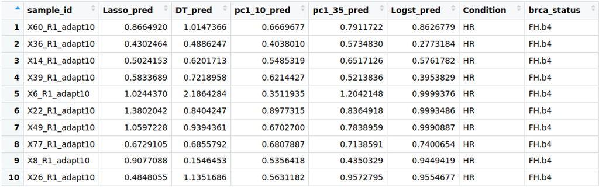

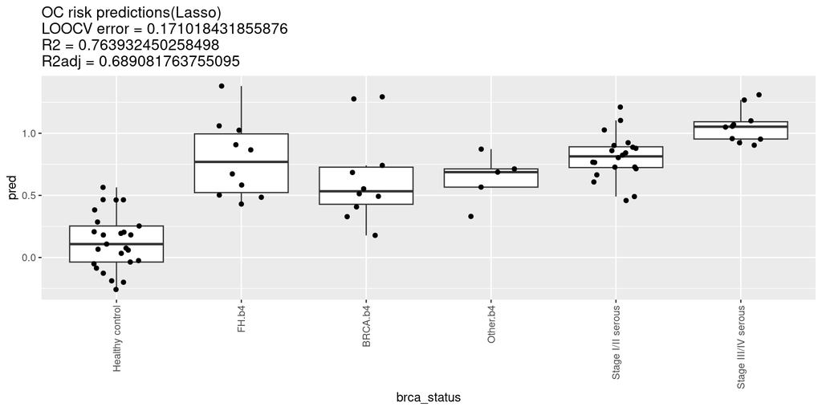

## Logistic Regression

- Similar to Lasso, trained the model using important (13) features
- Box-plot
- $\alpha$ = 0.5
- $\lambda$ (default)

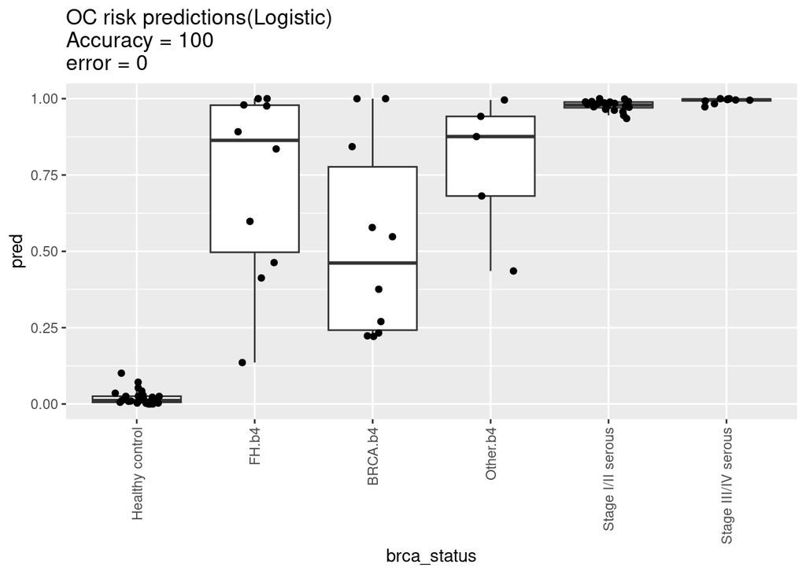

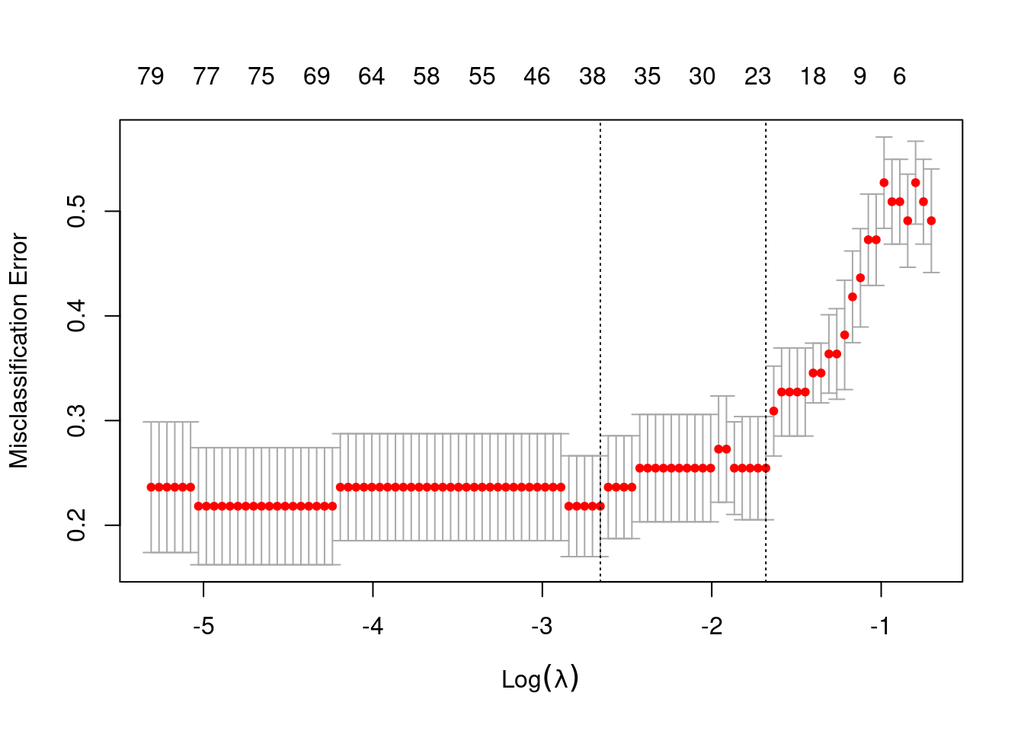

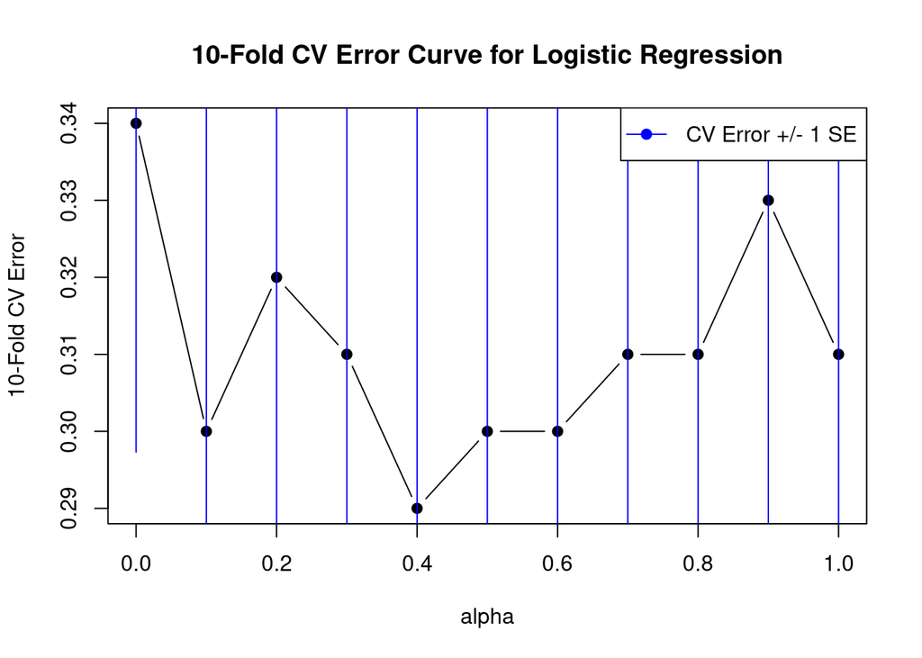

## Decision Tree

- Followed by logistic regression, a `decision tree` was trained using those 13 features
- Box-plot

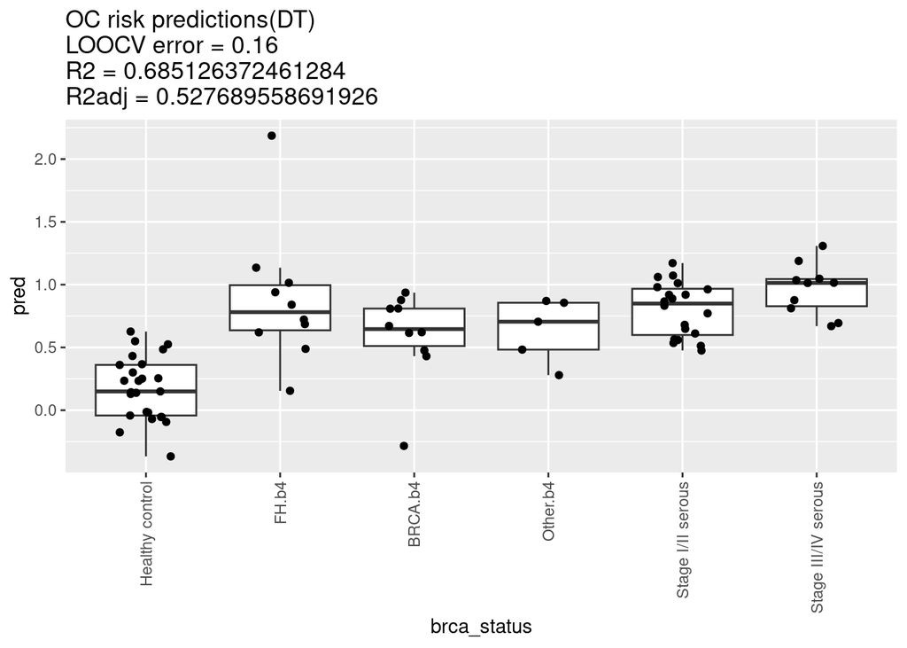

## PCA

- This initial pca model was trained using all the 403 features in the training dataset
- Biplot
- Scree
- PC (1-10)
- PC (1-35)

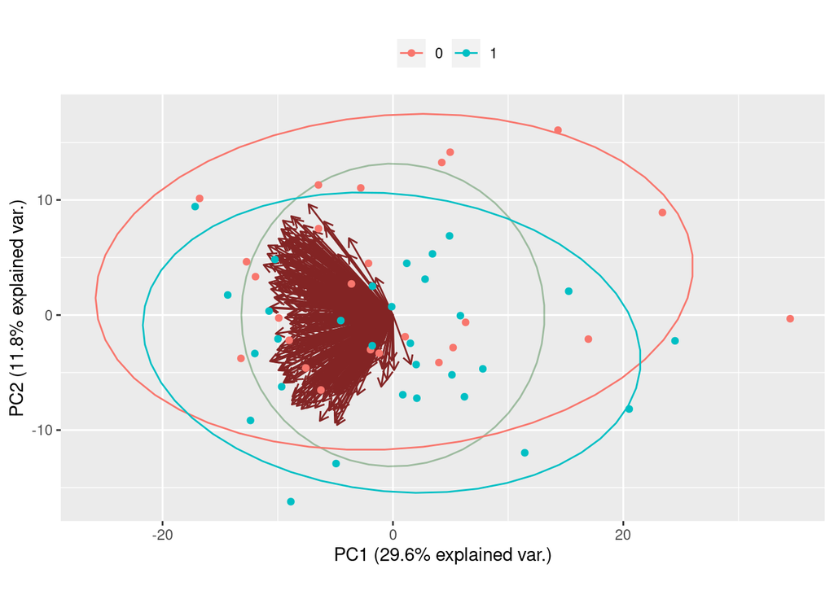

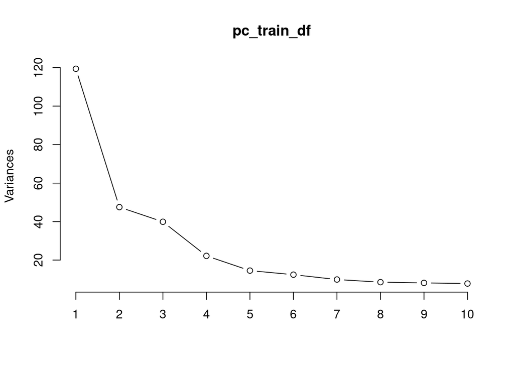

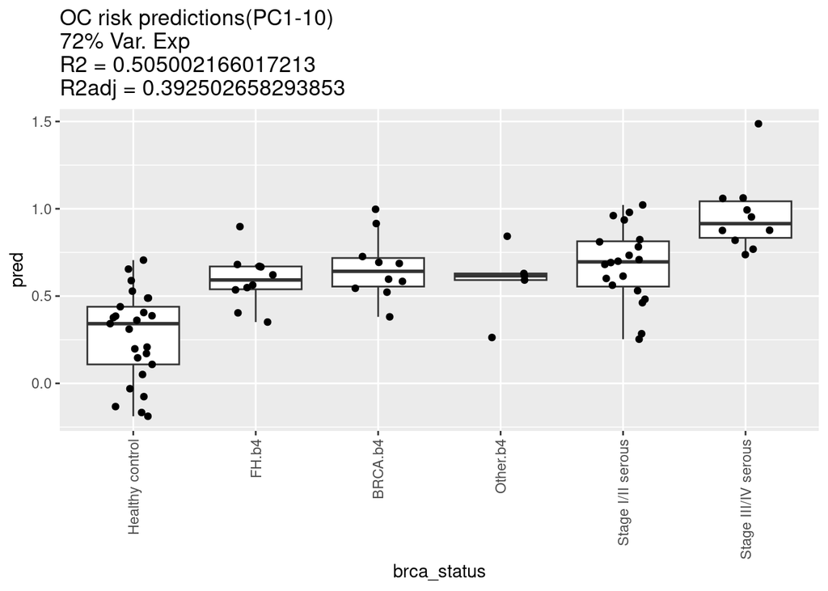

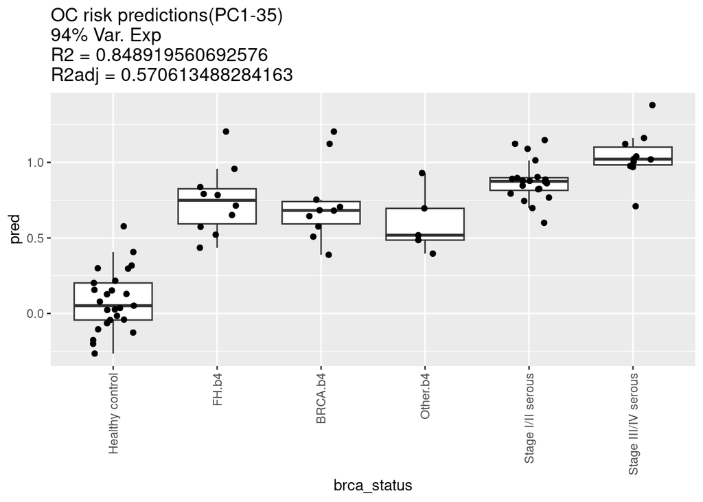

## PCA (contd…)

- Now, let look at the predictions of PCA model trained with Lasso selected (13) variables
- Biplot
- Scree
- Box

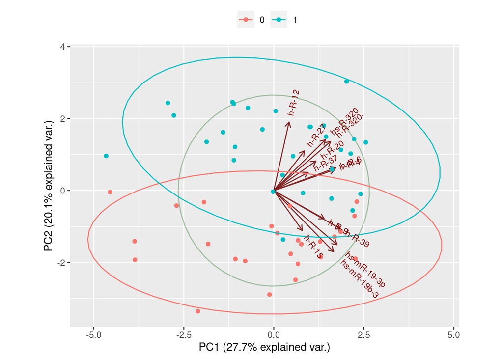

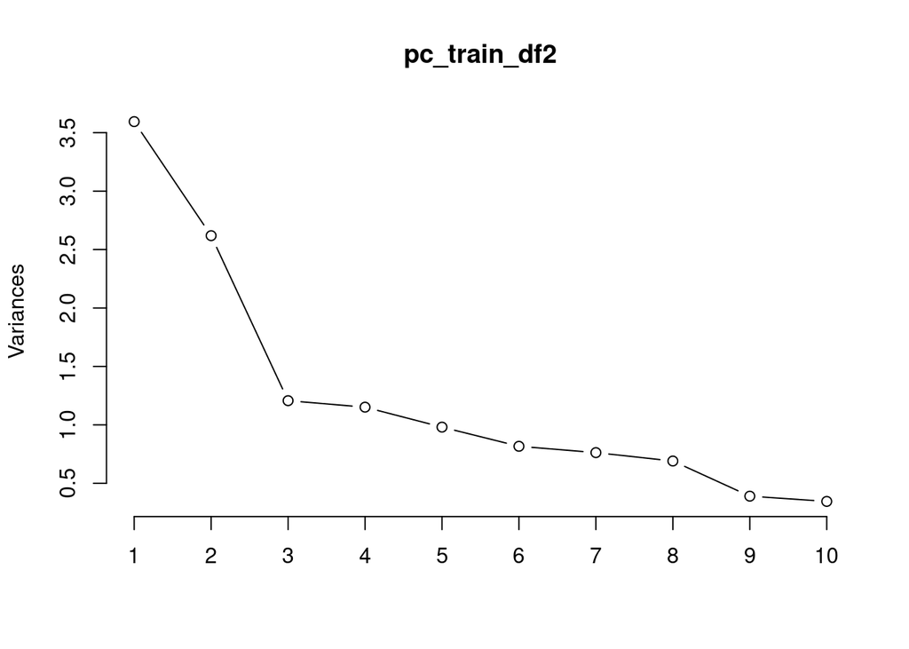

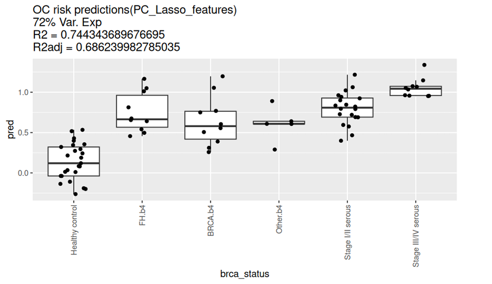

## Predictions

- Overview of the performance of all the models on the test-set
- Line Plot
- Line (no legend)
- CV error
- Table

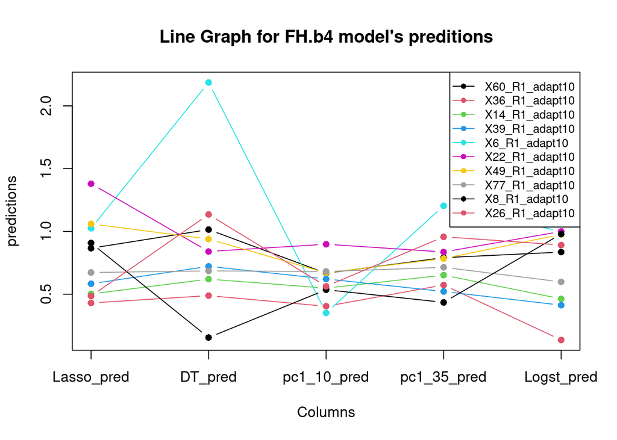

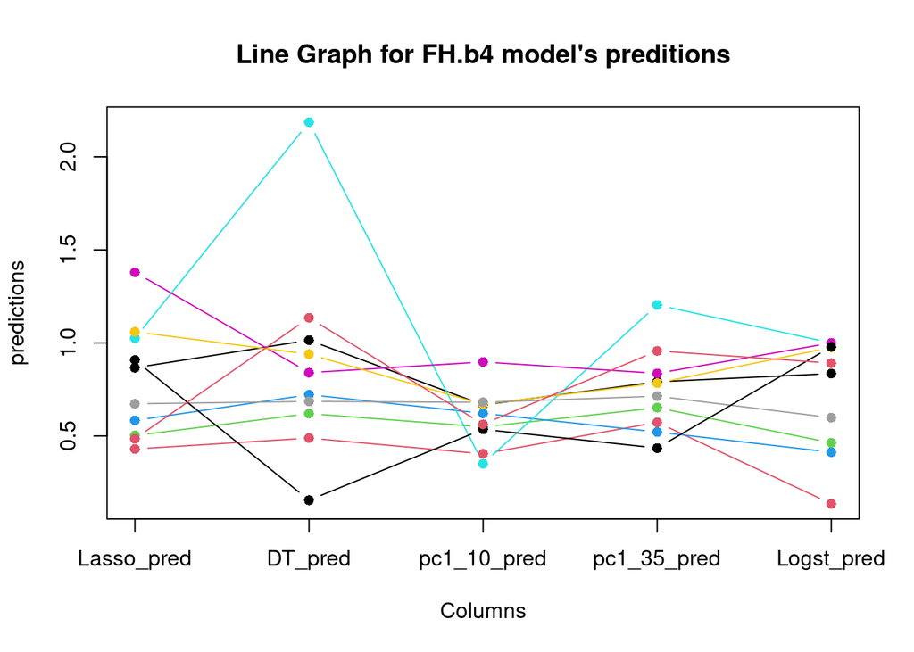

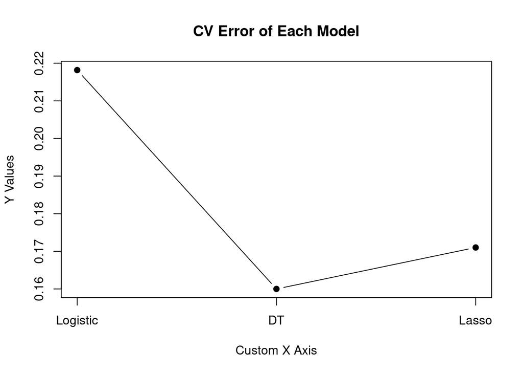

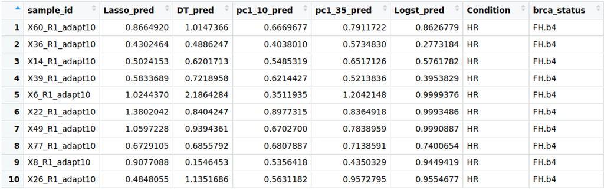